## **Logistic regression**

### **Data wrangling**

```r
library(GGally)
library(ggplot2)
library(ggpubr)
library(tidyr)
library(dplyr)
library(magrittr)
library(gmodels)
library(boot)
```

In this section Data wrangling has been done for two data sets retrieved from [UCI Machine Learning Repository](http://archive.ics.uci.edu/ml/datasets.html). The R script used for data wrangling can be found [here](https://github.com/melakbet/IODS-project/blob/master/data/create_alc.R)

### **Analysis**

The data sets used in this analysis were retrieved from the UCI Machine Learning Repository.The data sets are intend to approach student achievement in two secondary education Portuguese schools. The data was collected by using school reports and questionnaires that includes data attributes (student grades, demographic, social and school related features). Two datasets are provided regarding the performance in two distinct subjects: Mathematics (mat) and Portuguese language (por) (Cortez *et al*. 2008). For this analysis, the original dataset (mat and por) have been modified so that the two separate datasets have been joined. Only students who are answered the questionnaire in both Portuguese class are kept. The final data sets used in this analysis includes a total of 382 observation and 35 attributes.

```r
modified_data= read.table("data/modified_data.txt", sep="\t", header=TRUE)

colnames(modified_data)
```

```
##  [1] "school"     "sex"        "age"        "address"    "famsize"
##  [6] "Pstatus"    "Medu"       "Fedu"       "Mjob"       "Fjob"
## [11] "reason"     "nursery"    "internet"   "guardian"   "traveltime"
## [16] "studytime"  "failures"   "schoolsup"  "famsup"     "paid"
## [21] "activities" "higher"     "romantic"   "famrel"     "freetime"
## [26] "goout"      "Dalc"       "Walc"       "health"     "absences"
## [31] "G1"         "G2"         "G3"         "alc_use"    "high_use"
```

In order to study the relationship between high/low alcohol consumption and variables. I chose four variables (“absences”, “sex”, “goout” and “studytime”). My hypothesis about how each variable is related to alcohol consumption shown below:

- **studytime**: Students who dedicate quite much amount of time in their study, they don’t have time to go out for drinking alcohol (studytime and high/low alcohol consumption negatively correlated)
- **sex**: Male students have higher alcohol consumption than female students (Male students and high/low alcohol consumption positively correlated)
- **goout**: Those students going out with friends quite frequently consume high alcohol than students don’t going out. (goout and high/low alcohol consumption positively correlated)
- **absences**: Those students who consume more alcohol don’t attend class for various reason (e.g hangover, attending party in class time ) (absences and high/low alcohol consumption positively correlated)

##### **The distributions of my chosen variables and their relationships with alcohol consumption**

**A bar plot for demonstrating the distributions of my chosen variable**

```r
my_variables= c("absences", "sex", "goout", "studytime", "high_use")

my_variables_data <- select(modified_data, one_of(my_variables))

colnames(my_variables_data)
```

```
## [1] "absences"  "sex"       "goout"     "studytime" "high_use"
```

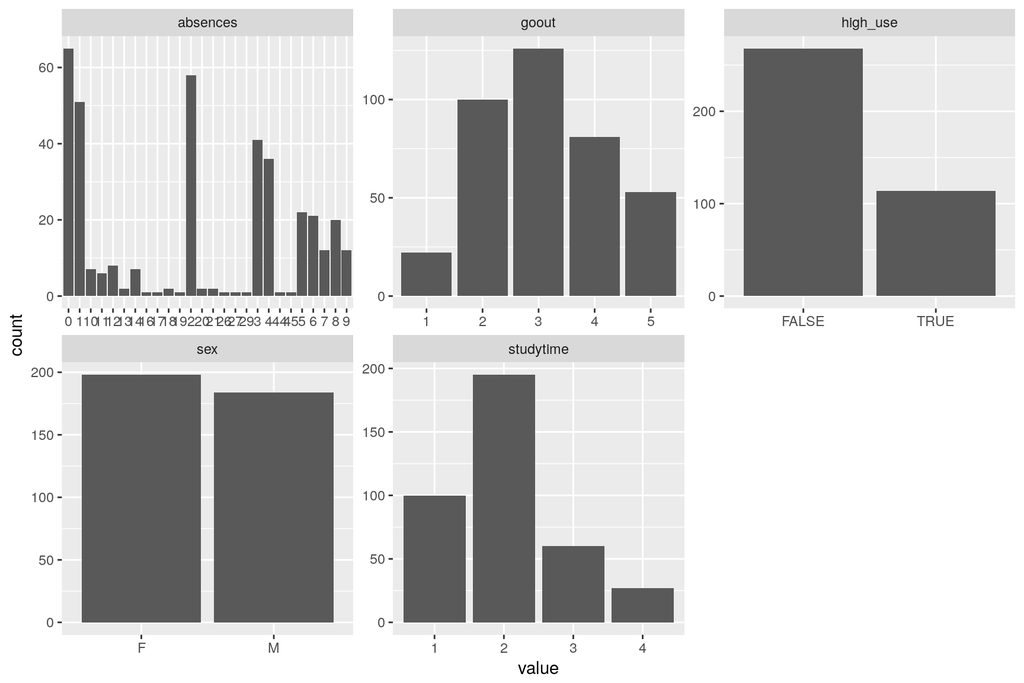

```r
gather(my_variables_data) %>% ggplot(aes(value)) + facet_wrap("key", scales = "free") + geom_bar()
```

**A Box plot for demonstrating my chosen variables and their relationships with alcohol consumption**

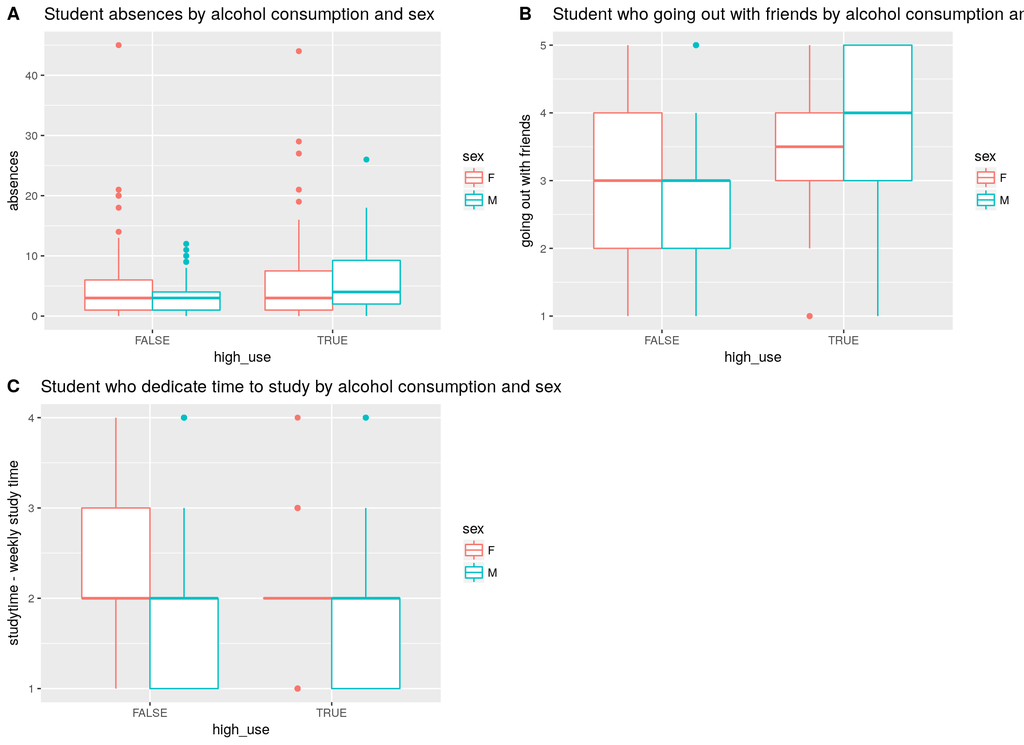

```r
g1 <- ggplot(modified_data, aes(x = high_use, y = absences,col=sex))

p1=g1 + geom_boxplot() + ylab("absences") + ggtitle("Student absences by alcohol consumption and sex")

g2 <- ggplot(modified_data, aes(x = high_use, y = goout, col=sex))

p2=g2 + geom_boxplot() + ylab("going out with friends")  + ggtitle("Student who going out with friends by alcohol consumption and sex")

g3 <- ggplot(modified_data, aes(x = high_use, y = studytime, col=sex))

p3=g3 + geom_boxplot() + ylab("studytime - weekly study time")  + ggtitle("Student who dedicate time to study by alcohol consumption and sex")

ggarrange(p1, p2, p3 , labels = c("A", "B","C"), ncol = 2, nrow = 2)
```

```r
#sex_high_use <- CrossTable(my_variables_data$sex, my_variables_data$high_use)
#goout_high_use <- CrossTable(my_variables_data$goout, my_variables_data$high_use)
#goout_high_use <- CrossTable(my_variables_data$goout, my_variables_data$high_use)
#studytime_high_use <- CrossTable(my_variables_data$studytime, my_variables_data$high_use)
```

To statistically explore the relationship between my chosen variable and high/low alcohol consumption variable logistic regression model was build using the R function `glm()`.

```r
m <- glm(high_use ~  absences + sex +  goout + studytime , data = modified_data, family = "binomial")
```

In order to be able to interpret the fitted model in detail, the summary, coefficients and confidence intervals of the fitted model are calculated as shown below.

```r
summary(m)
```

```
##
## Call:
## glm(formula = high_use ~ absences + sex + goout + studytime,
##     family = "binomial", data = modified_data)
##
## Deviance Residuals:
##     Min       1Q   Median       3Q      Max
## -1.9103  -0.7892  -0.5021   0.7574   2.6021
##
## Coefficients:
##             Estimate Std. Error z value Pr(>|z|)
## (Intercept) -3.20483    0.59429  -5.393 6.94e-08 ***
## absences     0.07811    0.02244   3.481 0.000499 ***
## sexM         0.78173    0.26555   2.944 0.003242 **
## goout        0.72677    0.11994   6.059 1.37e-09 ***
## studytime   -0.42116    0.17058  -2.469 0.013551 *
## ---
## Signif. codes:  0 '***' 0.001 '**' 0.01 '*' 0.05 '.' 0.1 ' ' 1
##
## (Dispersion parameter for binomial family taken to be 1)
##
##     Null deviance: 465.68  on 381  degrees of freedom
## Residual deviance: 381.31  on 377  degrees of freedom
## AIC: 391.31
##
## Number of Fisher Scoring iterations: 4
```

```r
coef(m)
```

```
## (Intercept)    absences        sexM       goout   studytime
## -3.20483157  0.07810746  0.78173290  0.72676824 -0.42116184
```

```r
OR <- coef(m) %>% exp
CI <- confint(m) %>% exp
cbind(OR,CI)
```

```
##                     OR      2.5 %    97.5 %
## (Intercept) 0.04056573 0.01222314 0.1263579
## absences    1.08123884 1.03577383 1.1324143
## sexM        2.18525582 1.30370562 3.7010763
## goout       2.06838526 1.64470314 2.6349716
## studytime   0.65628388 0.46510383 0.9099505
```

As shown above all the four variables are statistically significant. *goout* has the lowest p-value suggesting a strong association of going out with friends and high/low alcohol consumption. The positive coefficient for *goout* predictor suggests that all other variables being equal, going out with friends increase alcohol consumption. In the logit model, the response variable is log odds: $ln(odds) = ln(p/(1-p)) =\alpha+ \beta*x_1 + \beta*x_2 + … + \beta*x_n$. A unit increase in going out with friends increase the log odds by 0.72677. The variable *absences* and *sex* have also lowest p-vlaue 0.000499 and 0.003242, respectively. The positive coefficient for *absences* suggests that all other variables being equal, a unit increase in the *absences* increase alcohol consumption. A unit increase in absences increase the log odds by 0.07811. *sex* is also the other significant value with p-value (0.003242) and suggesting association of the sex of the student with high\low alcohol consumption. The positive coefficient for *sex* suggests that all other variables being equal, the male students are high likely alcohol consumption. The male student increase the log odds by 0.78173. *studytime* is also the other significant variable and the negative coefficient for this variable suggests that all other variables being equal, a unit increase in *studytime* reduces the alcohol consumption.A unit increase in studytime reduces the log odds by by 0.42116.

##### **Predictive power of the model**

```r
probabilities <- predict(m, type = "response")

# add the predicted probabilities to 'modified_data'

modified_data <- mutate(modified_data, probability = probabilities)

# use the probabilities to make a prediction of high_use

modified_data <- mutate(modified_data, prediction = probability>0.5)

table(high_use = modified_data$high_use, prediction = modified_data$prediction)
```

```
##         prediction
## high_use FALSE TRUE
##    FALSE   252   16
##    TRUE     65   49
```

```r
# the logistic regression model m and dataset alc (with predictions) are available

# define a loss function (average prediction error)
loss_func <- function(class, prob) {
  n_wrong <- abs(class - prob) > 0.5
  mean(n_wrong)
}

# compute the average number of wrong predictions in the (training) data
loss_func(modified_data$high_use, modified_data$probability)
```

```
## [1] 0.2120419
```

The above 2x2 cross tabulation indicates that out of 382 observations 81 (65+ 16) were wrongly predicated. The average proportion of incorrect predictions in the data is about 21%. My model has 21% error which is better than the model in DataCamp exercises.

**Bonus**

```r
# K-fold cross-validation

cv <- cv.glm(data = modified_data, cost = loss_func, glmfit = m, K = 10)

# average number of wrong predictions in the cross validation
cv$delta[1]
```

```
## [1] 0.2120419
```